# COLLEGE DATA

Introduction

one of the beautifull aspects of data is that it help us to make quick decisions about our day today questions. This short tutorial I will try to answer few common questions that someone applying to graduate school may have. Since everyones’ decision to apply specific school is based on his/her circumstance, I will consider someone with following circumstance:

```
- Want to apply graduate schools.
- schools must be in California.
- tuition must be under 30K.
_ School can be both Public or private.
- school must have higher acceptance rate of 50% and more.
the data contains school names, tuition fee, number of undergraduate students
```

```r
#install.package(tidyverse)
library(tidyverse)
college <- read.csv('http://672258.youcanlearnit.net/college.csv')
```

after you import the data, check if your data is clean or not.

```r
summary(college)
```

```
##        id                          name                city
##  Min.   :100654   Westminster College:   3   New York    :  15
##  1st Qu.:153250   Anderson University:   2   Boston      :  11
##  Median :186283   Aquinas College    :   2   Chicago     :  10
##  Mean   :186988   Bethany College    :   2   Philadelphia:   9
##  3rd Qu.:215284   Bethel University  :   2   Cleveland   :   8
##  Max.   :484905   Emmanuel College   :   2   Los Angeles :   8
##                   (Other)            :1256   (Other)     :1208
##      state           region      highest_degree    control      gender
##  PA     :101   Midwest  :353   Associate:  20   Private:763   CoEd :1237
##  NY     : 84   Northeast:299   Bachelor : 200   Public :506   Men  :   4
##  CA     : 71   South    :459   Graduate :1049                 Women:  28
##  TX     : 63   West     :158
##  OH     : 52
##  IL     : 47
##  (Other):851
##  admission_rate      sat_avg       undergrads       tuition
##  Min.   :0.0509   Min.   : 720   Min.   :   47   Min.   : 2732
##  1st Qu.:0.5339   1st Qu.: 973   1st Qu.: 1296   1st Qu.: 8970
##  Median :0.6687   Median :1040   Median : 2556   Median :20000
##  Mean   :0.6501   Mean   :1060   Mean   : 5629   Mean   :21025
##  3rd Qu.:0.7859   3rd Qu.:1120   3rd Qu.: 6715   3rd Qu.:30364
##  Max.   :1.0000   Max.   :1545   Max.   :52280   Max.   :51008
##
##  faculty_salary_avg loan_default_rate  median_debt         lon
##  Min.   : 1451      0.057  :  32      Min.   : 6056   Min.   :-157.92
##  1st Qu.: 6191      0.04   :  23      1st Qu.:21250   1st Qu.: -94.17
##  Median : 7272      0.046  :  22      Median :24589   Median : -84.89
##  Mean   : 7656      0.027  :  21      Mean   :23483   Mean   : -88.29
##  3rd Qu.: 8671      0.035  :  19      3rd Qu.:27000   3rd Qu.: -78.63
##  Max.   :20650      0.038  :  19      Max.   :41000   Max.   : -68.59
##                     (Other):1133
##       lat
##  Min.   :19.71
##  1st Qu.:35.22
##  Median :39.74
##  Mean   :38.61
##  3rd Qu.:41.81
##  Max.   :61.22
##
```

Now the data you see has two patterns. one has STAT summary(e.g. tuition, undergrads) starting with Min-Max, and another one has LIST Summary(e.g. name, state..)ending with (Other). those with Stat summary has NUMERIC CLASS, and those with LIST Summary has FACTOR CLASS..

The Loan_Default_rate do not have STAT SUMMARY but has a numeric values. check it out.

```r
class(college$loan_default_rate)
```

```
## [1] "factor"
```

we need to force it into numeric class. look at the summary Loan_default_rate has numeric class

```r
college <- college %>%
  mutate(loan_default_rate=as.numeric(loan_default_rate))
summary(college)
```

```
##        id                          name                city
##  Min.   :100654   Westminster College:   3   New York    :  15
##  1st Qu.:153250   Anderson University:   2   Boston      :  11
##  Median :186283   Aquinas College    :   2   Chicago     :  10
##  Mean   :186988   Bethany College    :   2   Philadelphia:   9
##  3rd Qu.:215284   Bethel University  :   2   Cleveland   :   8
##  Max.   :484905   Emmanuel College   :   2   Los Angeles :   8
##                   (Other)            :1256   (Other)     :1208
##      state           region      highest_degree    control      gender
##  PA     :101   Midwest  :353   Associate:  20   Private:763   CoEd :1237
##  NY     : 84   Northeast:299   Bachelor : 200   Public :506   Men  :   4
##  CA     : 71   South    :459   Graduate :1049                 Women:  28
##  TX     : 63   West     :158
##  OH     : 52
##  IL     : 47
##  (Other):851
##  admission_rate      sat_avg       undergrads       tuition
##  Min.   :0.0509   Min.   : 720   Min.   :   47   Min.   : 2732
##  1st Qu.:0.5339   1st Qu.: 973   1st Qu.: 1296   1st Qu.: 8970
##  Median :0.6687   Median :1040   Median : 2556   Median :20000
##  Mean   :0.6501   Mean   :1060   Mean   : 5629   Mean   :21025
##  3rd Qu.:0.7859   3rd Qu.:1120   3rd Qu.: 6715   3rd Qu.:30364
##  Max.   :1.0000   Max.   :1545   Max.   :52280   Max.   :51008
##
##  faculty_salary_avg loan_default_rate  median_debt         lon
##  Min.   : 1451      Min.   :  1.00    Min.   : 6056   Min.   :-157.92
##  1st Qu.: 6191      1st Qu.: 35.00    1st Qu.:21250   1st Qu.: -94.17
##  Median : 7272      Median : 55.00    Median :24589   Median : -84.89
##  Mean   : 7656      Mean   : 64.18    Mean   :23483   Mean   : -88.29
##  3rd Qu.: 8671      3rd Qu.: 83.00    3rd Qu.:27000   3rd Qu.: -78.63
##  Max.   :20650      Max.   :198.00    Max.   :41000   Max.   : -68.59
##
##       lat
##  Min.   :19.71
##  1st Qu.:35.22
##  Median :39.74
##  Mean   :38.61
##  3rd Qu.:41.81
##  Max.   :61.22
##
```

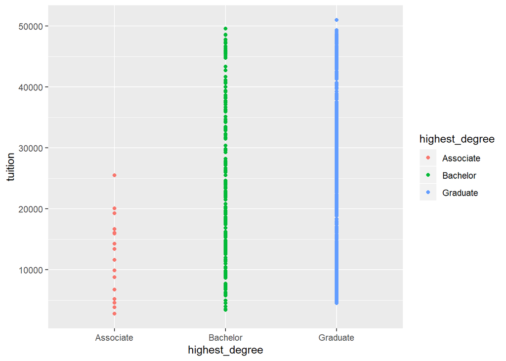

```r
college %>%
  arrange(desc(tuition))%>%
  select(name, tuition, region, highest_degree)%>%
  ggplot(aes(highest_degree, tuition, color = highest_degree))+
  geom_point()
```

This graph gives you good insight about the tuition in general. based on this graph tuition for grad school is in between ~5000 - 51000. in another words there is a chance this candidate will get school to apply in US that fits his/her financial condition.However we don’t know about California yet. let us check that now.

```
- schools must be in California.
```

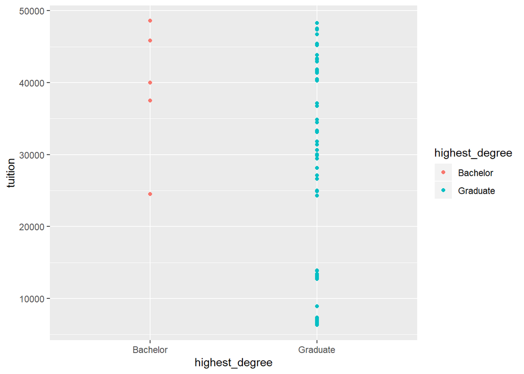

```r
college %>%
  filter(state =="CA")%>%
  arrange(desc(tuition))%>%
  select(name,state, tuition, region, highest_degree)%>%
  ggplot(aes(highest_degree, tuition, color = highest_degree))+
  geom_point()
```

from this graph we can tell that there are number of grad schools in California that has tuition under 30K. imagine if this candidate want to apply Bachelor. we got one school only. now I want to names of these grad schools which seem affordable.

```
- tuition must be under 30K:
```

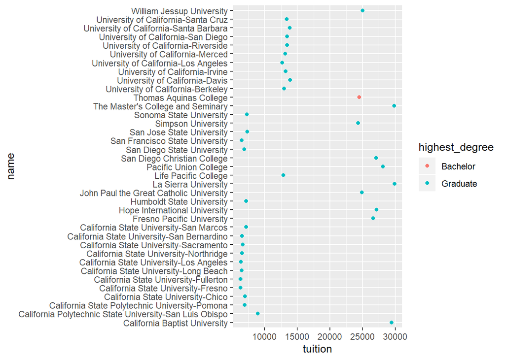

```r
college %>%
  filter(state =="CA"& tuition < 30000)%>%
  arrange(desc(tuition))%>%
  select(name,state, tuition, region, highest_degree)%>%
  ggplot(aes(name, tuition, color = highest_degree))+
  geom_point()+
  coord_flip()
```

well, now we got handfull schools which are fitting our criteria. However, the graph looks bit messy. look how one line of code can change the readability of this graph.

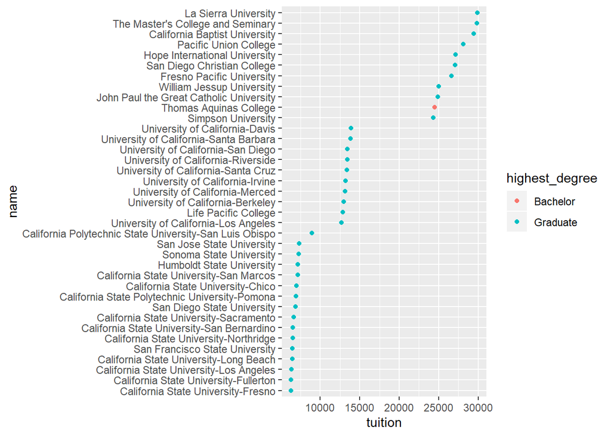

```r
college %>%
  filter(state =="CA"& tuition < 30000)%>%
  arrange(desc(tuition))%>%
  mutate(name = fct_reorder(name, tuition))%>%
  select(name,state, tuition, region, highest_degree)%>%
  ggplot(aes(name, tuition, color = highest_degree))+
  geom_point()+
  coord_flip()
```

well, now we got nice looking graph showing the school names. in case the candidate wanted to apply bachelor Thomas Aquinas College would have been the only option possible. However, our goal is not the bachelor, so I have to remove the bachelor and add admission criteria instead.

``- Want to apply graduate schools. _ School can be both Public or private. - acceptance rate must be higher than 50%.`

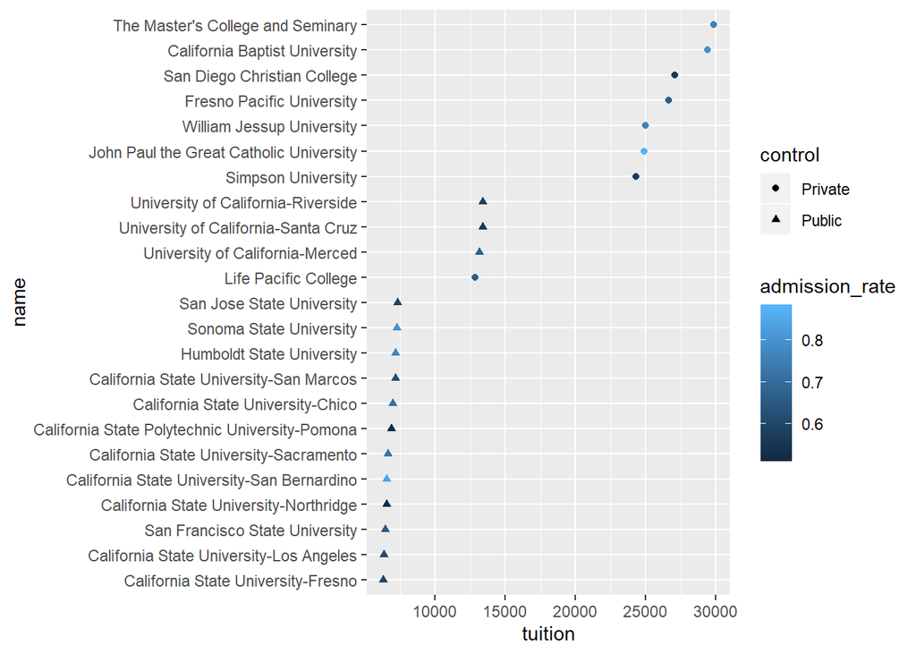

```r
college %>%
  filter(highest_degree =="Graduate"& state =="CA"& tuition < 30000& admission_rate >0.5)%>%
  arrange(desc(tuition))%>%
  mutate(name = fct_reorder(name, tuition))%>%
  select(name,state, tuition, region, highest_degree, control, admission_rate)%>%
  ggplot(aes(name, tuition, color = admission_rate,  shape =  control))+
  geom_point()+
  coord_flip()
```

It looks we got good number of schools fitting our criteria. at this point candidate may want to narrow his/her criteria where we can go down from here. however, the graph looks simple and readable. I just want to add titles/subtitle and dollar sign for better looking.

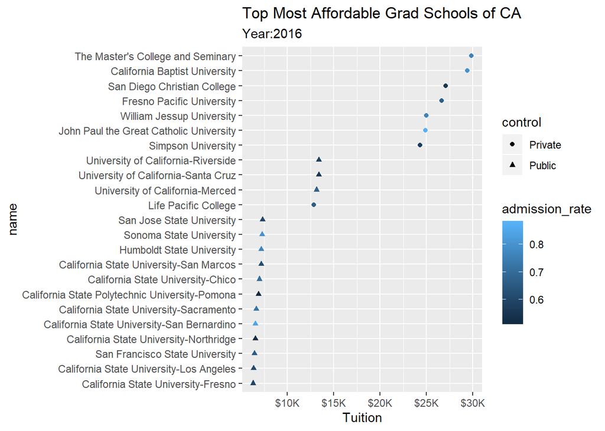

```r
college %>%
  filter(highest_degree=="Graduate" & state == "CA"&tuition < 30000 & admission_rate > 0.5)%>%
  mutate(name = fct_reorder(name, tuition))%>%
  select(name, state, highest_degree, tuition, control, admission_rate)%>%
  ggplot(aes(name, tuition, color = admission_rate,  shape =  control))+
  geom_point()+
  scale_y_continuous(name = "Tuition", breaks = c(10000, 15000, 20000, 25000,  30000), labels = c("$10K", "$15K", "$20K", "$25K", "$30K"))+
  labs(title = "Top Most Affordable Grad Schools of CA", subtitle = "Year:2016")+
  coord_flip()+
  geom_abline()
```